# CRWA Flagging Model - 2023 Update

Ayushman Choudhury

20 January 2023

# Introduction

My name is Ayushman Choudhury. I’m currently a sophomore at Brown University studying Applied Mathematics, Computer Science, and Music. For my Winternship with the Charles River Watershed Association, I updated the E. Coli Flagging Model, used to generate recommendations regarding water quality on the Charles River.

In this file, I have documented my process, including gathering data, wrangling it in R, and creating GLM and MLR models for each of CRWA’s 4 locations along the Charles River.

Boilerplate Text - this is an [R Markdown](http://rmarkdown.rstudio.com) Notebook. When code is executed within the notebook, the results appear beneath the code. Code can be executed by clicking the *Run* button within the chunk or by placing the cursor inside it and pressing *Cmd+Shift+Enter*.

```r
library(tidyverse)
library(lubridate)
library(dataRetrieval)
library(caret)
library(naniar)
set.seed(1)
```

# Section 1: Gathering Data

## 1.1 - E. Coli

The first data source is a copy of CRWA’s E. coli data from 2017 to 2022. These are the values that this model will predict. I did some basic selecting and Date/Time formatting in a Google Sheet, before loading the CSV in R. Here are the columns I used:

- Date_Collected - samples are weekly, typically on Thursdays
- Time_Collected - typically in the morning
- Site_ID - either 1NBS, 2LARZ, 3BU, or 4LONG
- Reporting_Result - E. coli. measured in cfu/100mL

In the following code, I access this CSV from my local “sources” folder, combine Date and Time into `datetime`, and round it to the nearest 10-minute interval. The tibble and dot plot give a quick overview.

```r
ecoliData <- read.csv("sources/ecoliWrangledCopy.csv") %>%
  mutate(datetime = round_date(
    as.POSIXct(
      paste(.$Date_Collected, .$Time_Collected),
      format = "%m/%d/%Y %H:%M:%S"),
    "10 minutes")) %>%
  select(datetime, Site_ID, Reporting_Result) %>%
  filter(.$Site_ID %in% c("1NBS", "2LARZ", "3BU", "4LONG"))

ecoliData %>% tibble()
```

```
## # A tibble: 627 × 3
##    datetime            Site_ID Reporting_Result
##    <dttm>              <chr>              <dbl>
##  1 2017-06-27 09:50:00 1NBS                 260
##  2 2017-06-27 09:20:00 2LARZ                 92
##  3 2017-06-27 09:00:00 3BU                   76
##  4 2017-06-27 08:40:00 4LONG                 16
##  5 2017-06-29 09:30:00 1NBS                 232
##  6 2017-06-29 08:50:00 2LARZ                332
##  7 2017-06-29 08:40:00 3BU                  124
##  8 2017-06-29 08:10:00 4LONG                 64
##  9 2017-07-06 09:50:00 1NBS                 150
## 10 2017-07-06 09:10:00 2LARZ                 50
## # … with 617 more rows
## # ℹ Use `print(n = ...)` to see more rows
```

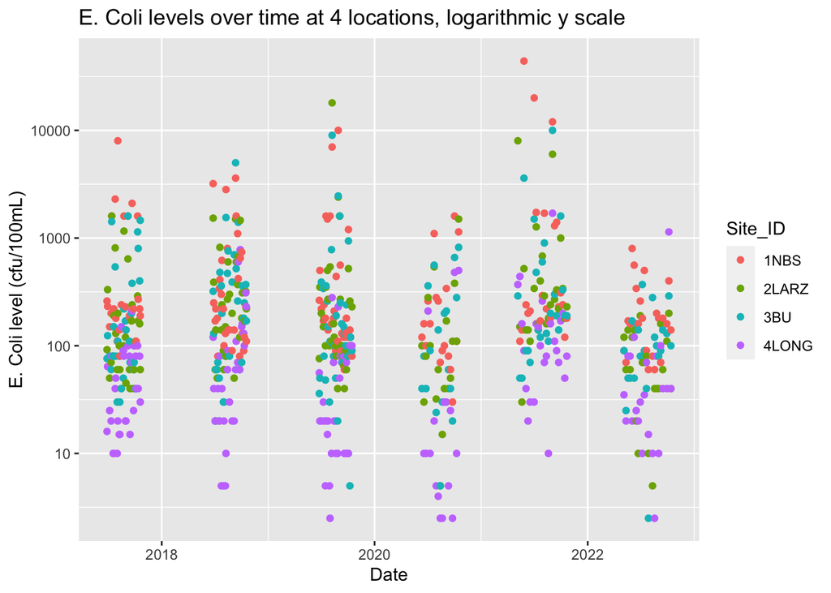

```r
ecoliData %>% ggplot(aes(x = datetime, y = Reporting_Result, color = Site_ID)) +
  geom_point() +
  scale_y_continuous(trans = 'log10') +
  ggtitle("E. Coli levels over time at 4 locations, logarithmic y scale") +
  labs(x = "Date", y = "E. Coli level (cfu/100mL)")
```

## 1.2 - Weather

The second data source is CRWA’s weather data. This is stored in several CSV files by year, from 2017 to 2022, each of which has about 26,000 rows. Each file has a different amount of metadata to skip — `read.csv()` has a skip parameter, but I just removed these rows manually in a text editor. The following code accesses them from my local “sources” folder.

```r
rawWeather2017 <- read.csv("sources/2017_Flagging_Season_2023_01_09_09_55_56_EST_1.csv")
rawWeather2018 <- read.csv("sources/2018_Flagging_Season_2023_01_09_09_54_55_EST_1.csv")
rawWeather2019 <- read.csv("sources/2019_Flagging_Season_2023_01_09_09_53_45_EST_1.csv")
rawWeather2020 <- read.csv("sources/2020_Flagging_Season_2023_01_09_09_44_11_EST_1.csv")
rawWeather2021 <- read.csv("sources/2021_Flagging_Season_2023_01_09_09_48_29_EST_1.csv")
rawWeather2022 <- read.csv("sources/2022_Flagging_Season_2023_01_09_09_50_04_EST_1.csv")
```

There’s some wrangling to do here too:

1. Each file has its columns in a different order, so I standardized this order as Pressure, PAR, Rain, RH%, Wind Dir, Wind Speed, Gust Speed, DewPt, Air Temp, Water Temp. (Temperatures are in Fahrenheit).
2. For some data points, the values jump between several different columns. I merged these together.

```r
#2017 --
colnames(rawWeather2017) = c("id", "time", "pressure", "par", "rain", "rh", "gustSpeed", "dewPt", "windDir", "airTemp", "windSpeed", "waterTemp")

weather2017 <- rawWeather2017 %>%
  mutate(waterTemp = ifelse(waterTemp > 32, waterTemp, NA)) %>%
  mutate(datetime = as.POSIXct(time, format = "%m/%d/%y %H:%M:%S")) %>%
  select(datetime, pressure, par, rain, rh, windDir, windSpeed, gustSpeed, dewPt, airTemp, waterTemp)

#2018 --
colnames(rawWeather2018) = c("id", "time", "pressure", "par", "rain", "rh", "windSpeed", "gustSpeed", "dewPt", "windDir", "waterTemp2", "airTemp3", "airTemp2", "airTemp1", "waterTemp1", "waterTempNull")

weather2018 <- rawWeather2018 %>%
  mutate(waterTemp = ifelse(is.na(waterTemp2), waterTemp1, waterTemp2)) %>%
  mutate(airTemp = ifelse(is.na(airTemp3), ifelse(is.na(airTemp2), airTemp1, airTemp2), airTemp3)) %>%
  mutate(datetime = as.POSIXct(time, format = "%m/%d/%y %H:%M:%S")) %>%
  select(datetime, pressure, par, rain, rh, windDir, windSpeed, gustSpeed, dewPt, airTemp, waterTemp)

#2019 --
colnames(rawWeather2019) = c("id", "time", "pressure", "par", "rain", "rh", "windSpeed", "gustSpeed", "dewPt", "windDir", "waterTemp", "airTemp")

weather2019 <- rawWeather2019 %>%
  mutate(datetime = as.POSIXct(time, format = "%m/%d/%y %H:%M:%S")) %>%
  select(datetime, pressure, par, rain, rh, windDir, windSpeed, gustSpeed, dewPt, airTemp, waterTemp)

#2020 --
colnames(rawWeather2020) = c("id", "time", "pressure", "par", "rain", "rh", "windSpeed", "gustSpeed", "dewPt1", "windDir1", "airTemp1", "waterTemp1", "waterTemp2", "dewPt2", "windDir2", "airTemp2")

weather2020 <- rawWeather2020 %>%
  mutate(dewPt = ifelse(is.na(dewPt2), dewPt1, dewPt2)) %>%
  mutate(windDir = ifelse(is.na(windDir2), windDir1, windDir2)) %>%
  mutate(airTemp = ifelse(is.na(airTemp2), airTemp1, airTemp2)) %>%
  mutate(waterTemp = NA) %>%
  mutate(datetime = as.POSIXct(time, format = "%m/%d/%y %H:%M:%S")) %>%
  select(datetime, pressure, par, rain, rh, windDir, windSpeed, gustSpeed, dewPt, airTemp, waterTemp)

#2021 --
colnames(rawWeather2021) = c("id", "time", "pressure", "par", "rain", "rh", "windSpeed", "gustSpeed", "dewPt1", "windDir1", "airTemp1", "waterTempNull", "dewPt2", "windDir2", "tempUnknown", "airTemp2")

weather2021 <- rawWeather2021 %>%
  mutate(dewPt = ifelse(is.na(dewPt2), dewPt1, dewPt2)) %>%
  mutate(windDir = ifelse(is.na(windDir2), windDir1, windDir2)) %>%
  mutate(airTemp = ifelse(is.na(airTemp2), airTemp1, airTemp2)) %>%
  mutate(waterTemp = tempUnknown) %>%
  mutate(datetime = as.POSIXct(time, format = "%m/%d/%y %H:%M:%S")) %>%
  select(datetime, pressure, par, rain, rh, windDir, windSpeed, gustSpeed, dewPt, airTemp, waterTemp)

#2022 --
colnames(rawWeather2022) = c("id", "time", "pressure", "par", "rain", "rh", "dewPt", "windDir", "waterTemp", "airTemp", "windSpeed", "gustSpeed")

weather2022 <- rawWeather2022 %>%
  mutate(datetime = as.POSIXct(time, format = "%m/%d/%y %H:%M:%S")) %>%
  select(datetime, pressure, par, rain, rh, windDir, windSpeed, gustSpeed, dewPt, airTemp, waterTemp)
```

We can stack all of these together to create a large (158,116 x 11) dataset for all of the weather data. Here’s a quick tibble to show the results.

```r
weatherData <- rbind(weather2017, weather2018, weather2019, weather2020, weather2021, weather2022)

weatherData %>% tibble()
```

```
## # A tibble: 158,116 × 11
##    datetime            pressure   par  rain    rh windDir windSp…¹ gustS…² dewPt
##    <dttm>                 <dbl> <dbl> <dbl> <dbl>   <dbl>    <dbl>   <dbl> <dbl>
##  1 2017-05-01 00:00:00     30.2     1     0  74.9     157      3.4    11.9  40.8
##  2 2017-05-01 00:10:00     30.2     1     0  75.1     160      6      12.8  40.9
##  3 2017-05-01 00:20:00     30.2     1     0  74.8     163      2.6     9.4  41.3
##  4 2017-05-01 00:30:00     30.2     1     0  71.4     168      7.7    17.9  39.9
##  5 2017-05-01 00:40:00     30.2     1     0  70.1     164      6      17.9  39.6
##  6 2017-05-01 00:50:00     30.2     1     0  70.1     157      2.6    11.9  39.6
##  7 2017-05-01 01:00:00     30.2     1     0  70.5     170      3.4    11.1  39.6
##  8 2017-05-01 01:10:00     30.2     1     0  69.9     175      3.4    11.1  39.4
##  9 2017-05-01 01:20:00     30.2     1     0  68.6     167      6      13.6  38.9
## 10 2017-05-01 01:30:00     30.2     1     0  65.2     180      5.1    14.5  37.5
## # … with 158,106 more rows, 2 more variables: airTemp <dbl>, waterTemp <dbl>,
## #   and abbreviated variable names ¹windSpeed, ²gustSpeed
## # ℹ Use `print(n = ...)` to see more rows, and `colnames()` to see all variable names
```

## 1.3 - USGS Water Data - discharge

The final data source is USGS’s water data regarding discharge. USGS has a specific R library `dataRetrieval` which I use below. The location is in Waltham, MA on the Charles River (site number 01104500). Below, I access the discharge data (code 00060) from the beginning of 2017 to the end of 2022.

```r
waltham <- readNWISuv(siteNumbers = "01104500",
                      parameterCd = "00060",
                      startDate = "2017-01-01",
                      endDate = "2022-12-31") %>%
  renameNWISColumns()
```

Retrieving this data from USGS can take some time, but once it is done we can include it as yet another predictor. Here’s a quick plot of the flow during 2022.

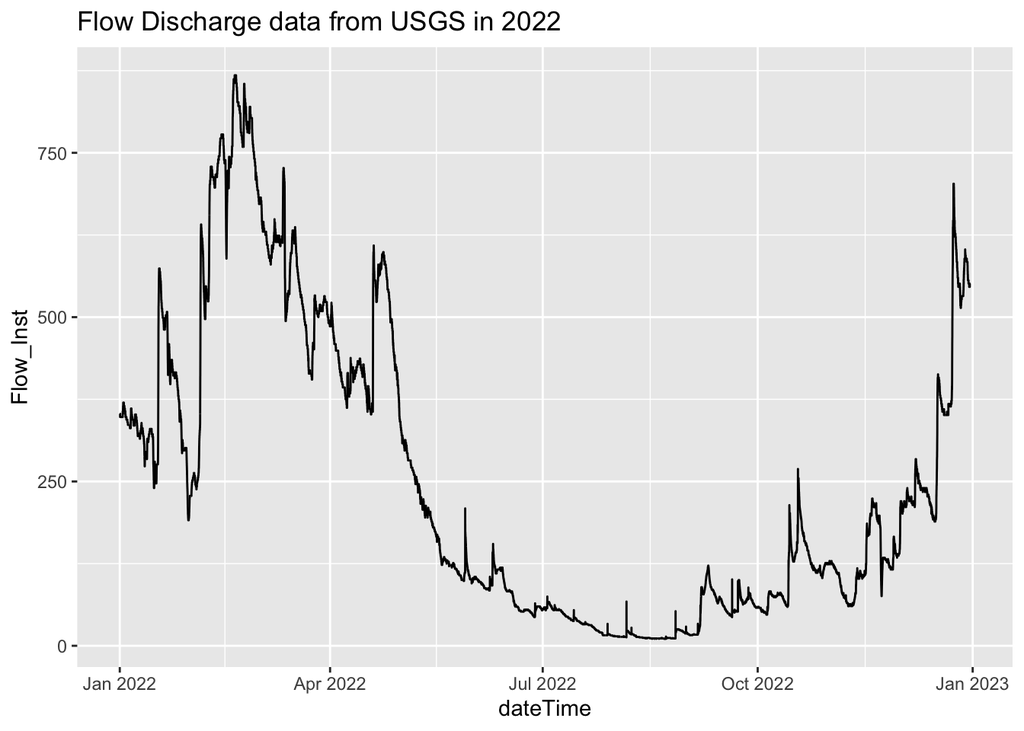

```r
waltham %>%
  filter(dateTime >= as.Date('2022-01-01'), dateTime <= as.Date('2022-12-31')) %>%
  ggplot(aes(dateTime, Flow_Inst)) +
  geom_line() +
  ggtitle("Flow Discharge data from USGS in 2022")
```

# Section 2: Defining Features and Outcomes

## 2.1 - Strategy

We have 627 E. Coli measurements. To predict these measurements, we should have 627 sets of features from which to train our model. The simplest choice would be to only use the 627 rows at the times the E. Coli sample was recorded. However, since E. Coli populations can depend on the conditions of the water over the previous hour or day (and since we have a lot more than 627 rows), we can also include averages of the flow and weather values over the previous 1 hour, 12 hours, 24 hours, 48 hours, and 72 hours.

We can be even more specific with the rainfall values. CRWA has previously used these variables (credit to Eli Kane):

- 12 hour intervals: 0-12, 12-24, 24-36, 36-48, 48-60, 60-72, 72-84, 84-96
- 24 hour intervals: 0-24, 24-48, 48-72, 72-96
- 48 hour intervals: 0-48, 48-96
- Prior week: 0-168
- Days since last rain & Days since last major rain (> 0.1 inches)

For averages, I will be using the geometric mean over the arithmetic mean, to lessen the effect of outliers. This can be calculated as `exp(mean(log(data)))`.

## 2.2 - Flow Features

For each E. coli measurement time, I:

- Calculate its index in the flow data frame
- Get the Geometric means of the flow 1/12/24/48/72 hours prior using `sapply`

Once these values are stored, I transpose the matrix, cast it to a data frame, and adjust the column/row names.

```r
flowFeaturesSeparate <- sapply(ecoliData$datetime, function(x) {
  flowIndex <- length(which(waltham$dateTime <= x))

  flowTimes <- c(1,12,24,48,72) * 4 - 1

  sapply(flowTimes, function(x){
    exp(mean(log(waltham$Flow_Inst[(flowIndex - x):flowIndex])))
  })
})

flowFeatures <- flowFeaturesSeparate %>%
  data.frame() %>% t() %>% data.frame()

colnames(flowFeatures) = c("hourAvgFlow", "halfDayAvgFlow", "dayAvgFlow", "twoDayAvgFlow", "threeDayAvgFlow")

row.names(flowFeatures) <- NULL
```

## 2.3 - Rainfall Total Features

Here, I use multiple sapply calls for each range.

```r
rainfallFeaturesSeparate <- sapply(ecoliData$datetime, function(x) {
  weatherIndex = length(which(weatherData$datetime <= x))

  halfDayIntervals <- sapply(seq(12,96,12), function(t) {
    sum(weatherData$rain[(weatherIndex - t*6):(weatherIndex - (t + 12)*6)])
  })

  dayIntervals <- sapply(seq(24,96,24), function(t) {
    sum(weatherData$rain[(weatherIndex - t*6):(weatherIndex - (t + 24)*6)])
  })

  twoDayIntervals <- sapply(seq(48,96,48), function(t) {
    sum(weatherData$rain[(weatherIndex - t*6):(weatherIndex - (t + 48)*6)])
  })

  weekRain <- sum(weatherData$rain[(weatherIndex - 6*24*7):(weatherIndex)])

  c(halfDayIntervals, dayIntervals, twoDayIntervals, weekRain)
})

rainfallFeatures <- rainfallFeaturesSeparate %>%
  data.frame() %>% t() %>% data.frame()

colnames(rainfallFeatures) = c(
  "rain0_12", "rain12_24", "rain24_36", "rain36_48", "rain48_60", "rain60_72", "rain72_84", "rain84_96",
  "rain0_24", "rain24_48", "rain48_72", "rain72_96",
  "rain0_48", "rain48_96", "rainWeek")

row.names(rainfallFeatures) = NULL
```

## 2.4 - Periodic Rain Features

For each E. coli measure time, I run a loop:

- Using a day counter,
- While the time range is still valid, and the year is the same as the original measure time’s year,
- I find the max rain value between the day counter and the original measure time.
  - If it is > 0.1, this is a major rain event. Break.
  - Else if it is > 0, this is a rain event. Continue looking for a major rain event.
  - Else, continue looking.

**Since rain values aren’t collected year-round, this metric might not be useful for E. coli observations during dry days at the beginning of the weather data collection period.**

**This is not an issue in this scope, because weather data is collected starting on May 1st and E. coli data is collected starting at the end of June, and there has always been some rainfall between these two months.**

**However, it could become an issue if E. coli data was collected closer to May 1st, before the first rainfall of the season.**

```r
rainPeriodSeparate <- sapply(ecoliData$datetime, function(x) {
  year <- format(
    as.POSIXct(x, origin = "1970-01-01"),
    format = "%Y")

  originalIndex = length(which(weatherData$datetime <= x))

  daysSinceLastRain <- 365
  daysSinceLastMajorRain <- 365
  day <- 0

  while (((originalIndex - day*6*24) > 1)
         &
         (format(as.POSIXct(weatherData$datetime[originalIndex]), "%Y") == year)) {

    maxRain <- max(weatherData$rain[(originalIndex - day*6*24):originalIndex])

    if (maxRain > 0.1) {
      daysSinceLastMajorRain <- day
      if (day < daysSinceLastRain) {
        daysSinceLastRain <- day
      }
      break
    } else if (maxRain > 0) {
      if (day < daysSinceLastRain) {
        daysSinceLastRain <- day
      }
    }
    day <- day + 1
  }#Close while loop

  c(daysSinceLastRain, daysSinceLastMajorRain)
})

rainPeriod <- rainPeriodSeparate %>%
  data.frame() %>% t() %>% data.frame()

colnames(rainPeriod) <- c("daysSinceLastRain", "daysSinceLastMajorRain")

row.names(rainPeriod) <- NULL
```

## 2.5 - Other Weather Features

This is similar to the code for 2.2 - Flow Features except with more metrics in the sapply, that are concatenated together.

```r
weatherFeaturesSeparate <- sapply(ecoliData$datetime, function(x) {
  weatherIndex <- length(which(weatherData$datetime <= x))

  weatherTimes <- c(1, 12, 24, 28, 72) * 6

  weatherTempArray <- sapply(weatherTimes, function(x) {
    c(
      exp(mean(log(weatherData$pressure[(weatherIndex - x):weatherIndex]))),
      exp(mean(log(weatherData$par[(weatherIndex - x):weatherIndex]))),
      exp(mean(log(weatherData$rh[(weatherIndex - x):weatherIndex]))),
      exp(mean(log(weatherData$windSpeed[(weatherIndex - x):weatherIndex]))),
      exp(mean(log(weatherData$gustSpeed[(weatherIndex - x):weatherIndex]))),
      exp(mean(log(weatherData$dewPt[(weatherIndex - x):weatherIndex]))),
      exp(mean(log(weatherData$airTemp[(weatherIndex - x):weatherIndex]))),
      exp(mean(log(weatherData$waterTemp[(weatherIndex - x):weatherIndex])))
    )
  })

  c(t(weatherTempArray))
})

weatherFeatures <- weatherFeaturesSeparate %>%
  data.frame() %>% t() %>% data.frame()

colnames(weatherFeatures) <- c(
  "hourAvgPressure", "halfDayAvgPressure", "dayAvgPressure", "twoDayAvgPressure", "threeDayAvgPressure",
  "hourAvgPAR", "halfDayAvgPAR", "dayAvgPAR", "twoDayAvgPAR", "threeDayAvgPAR",
  "hourAvgRH", "halfDayAvgRH", "dayAvgRH", "twoDayAvgRH", "threeDayAvgRH",
  "hourAvgWind", "halfDayAvgWind", "dayAvgWind", "twoDayAvgWind", "threeDayAvgWind",
  "hourAvgGust", "halfDayAvgGust", "dayAvgGust", "twoDayAvgGust", "threeDayAvgGust",
  "hourAvgDew", "halfDayAvgDew", "dayAvgDew", "twoDayAvgDew", "threeDayAvgDew",
  "hourAvgAirTemp", "halfDayAvgAirTemp", "dayAvgAirTemp", "twoDayAvgAirTemp", "threeDayAvgAirTemp",
  "hourAvgWaterTemp", "halfDayAvgWaterTemp", "dayAvgWaterTemp", "twoDayAvgWaterTemp", "threeDayAvgWaterTemp")

row.names(weatherFeatures) <- NULL
```

## 2.6 - Putting the Features Together

Now, we `cbind` all four data frames together. For each of the 627 observations, we now have `datetime`, `year`, and 62 environmental features, to use in the prediction models.

```r
features <- cbind(ecoliData$datetime,
                  (format(as.POSIXct(ecoliData$datetime), "%Y")),
                  flowFeatures, rainfallFeatures, rainPeriod, weatherFeatures)

names(features)[1] <- 'datetime'
names(features)[2] <- 'year'

dim(features)
```

```
## [1] 627  64
```

## 2.7 - Checking Completeness of Features

Before constructing the model, we should check the completeness of the Features data frame.

### 2.7.1 - NAs

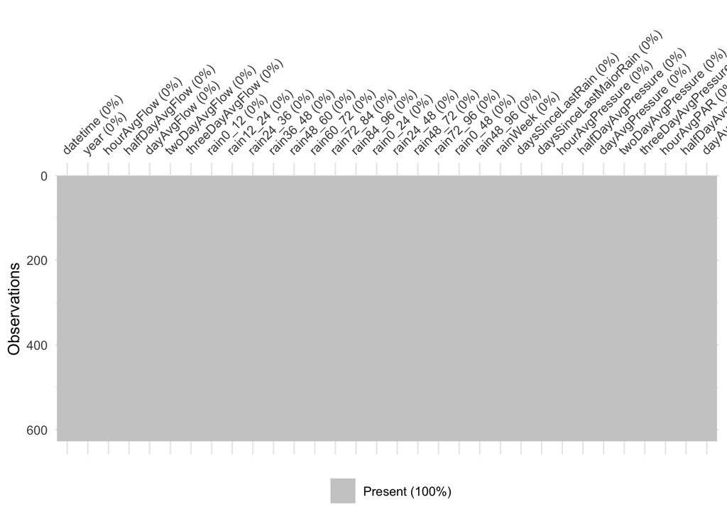

```r
vis_miss(features[,1:32])
```

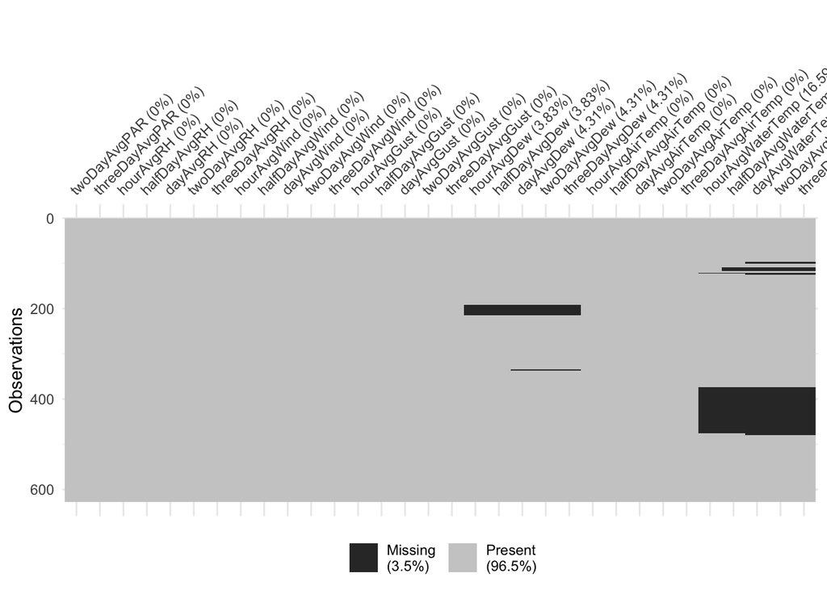

```r
vis_miss(features[,33:64])
```

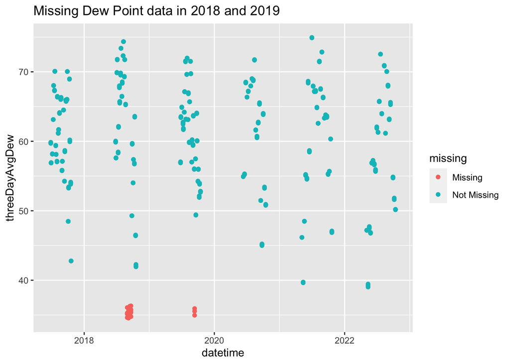

```r
features %>% ggplot(aes(datetime, threeDayAvgDew)) +
  geom_miss_point() +
  ggtitle("Missing Dew Point data in 2018 and 2019")
```

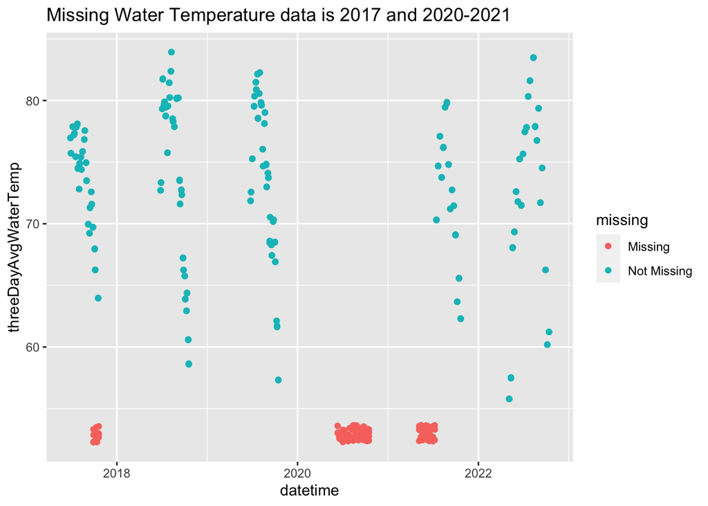

```r
features %>% ggplot(aes(datetime, threeDayAvgWaterTemp)) +
  geom_miss_point() +
  ggtitle("Missing Water Temperature data is 2017 and 2020-2021")
```

Based on these results,

- We will not be using the DewPt data, since it is not particularly relevant to E. coli.
- We want to use the waterTemp data, since it is relevant to E. coli, so we will remove the rows for which `threeDayAvgWaterTemp` is null.

```r
ecoliData <- ecoliData %>%
  filter(!is.na(features$threeDayAvgWaterTemp))

features <- features %>%
  select(!c(hourAvgDew, halfDayAvgDew, dayAvgDew, twoDayAvgDew, threeDayAvgDew)) %>%
  filter(!is.na(features$threeDayAvgWaterTemp))
```

### 2.7.2 - Flawed Values

Just because the data exists doesn’t mean that it is reliable. We should also check that the values are reasonable (no negative rainfalls, extreme temperatures, etc.) To do this, I created boxplots by year of every feature.

```r
completionBoxPlots <- lapply(names(features)[3:59], function(colName) {
  ggplot(features, aes_string(x = "year", y = colName)) +
    geom_boxplot(outlier.color = "red", outlier.size = 3) +
    coord_flip()
})
```

So, we will not consider wind speed or gust speed.

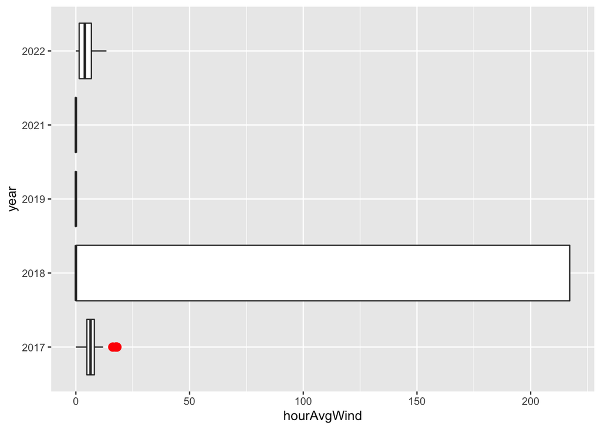

```r
completionBoxPlots[which(names(features) == "hourAvgWind") - 2]
```

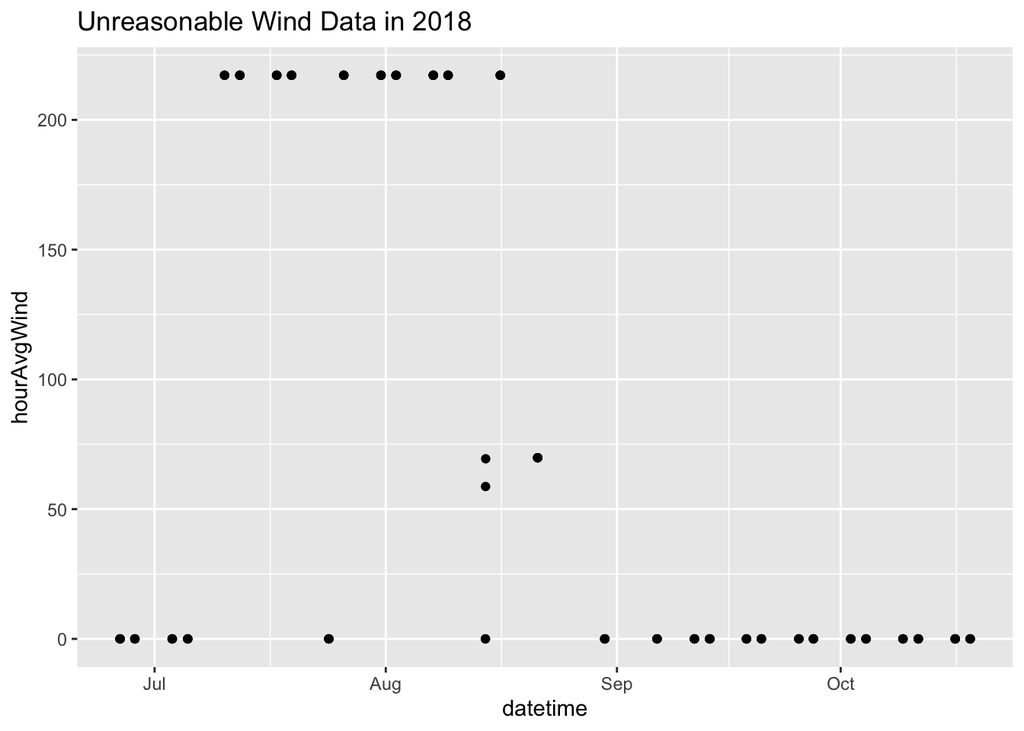

```r
features %>%
  filter(year == 2018) %>%
  ggplot(aes(datetime, hourAvgWind)) +
  geom_point() +
  ggtitle("Unreasonable Wind Data in 2018")
```

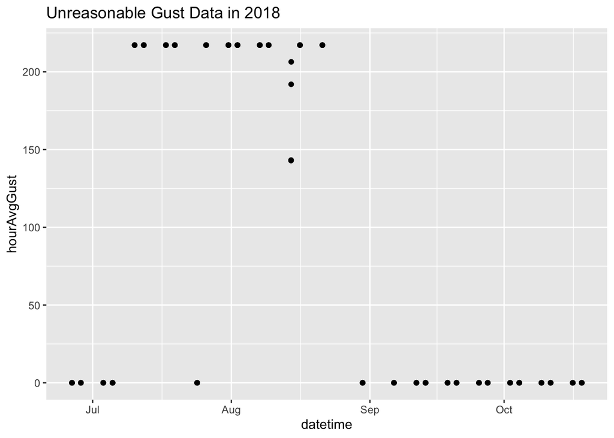

```r
features %>%
  filter(year == 2018) %>%
  ggplot(aes(datetime, hourAvgGust)) +
  geom_point() +
  ggtitle("Unreasonable Gust Data in 2018")
```